# Poplar (T89 - OP42) Cambium adventitious roots studies biological QA

Nicolas Delhomme & Alok Ranjan

2017-07-03

# 1 Setup

Set the working dir

```r
setwd("/mnt/picea/projects/aspseq/cbellini/24_Bellini_cambium")
```

Load libraries

```r
suppressPackageStartupMessages(library(DESeq2))
suppressPackageStartupMessages(library(dendextend))
suppressPackageStartupMessages(library(gplots))
suppressPackageStartupMessages(library(pander))
suppressPackageStartupMessages(library(parallel))
suppressPackageStartupMessages(library(RColorBrewer))
suppressPackageStartupMessages(library(scatterplot3d))
suppressPackageStartupMessages(library(vsn))
```

Source some helper functions

```r
source("~/Git/UPSCb/src/R/plot.multidensity.R")
```

Create palettes

```r
pal <- brewer.pal(8,"Dark2")
hpal <- colorRampPalette(c("blue","white","red"))(100)
```

Register the default plot margin

```r
mar <- par("mar")
```

# 2 Process

## 2.1 All samples

Read the sample information

```r
samples <- read.csv("~/Git/UPSCb/projects/bellini_cambium/doc/samples.csv")
```

Read the HTSeq files in a matrix

```r
res <- mclapply(dir("htseq",pattern="*.txt",full.names=TRUE),function(fil){
  read.delim(fil,header=FALSE,stringsAsFactors=FALSE)
},mc.cores=max(mcaffinity()))

# Rename the HTSeq files
names(res) <- samples$SampleName[match(sub("(_L[1,2])?_sortmerna.*\\.txt","",dir("htseq",pattern="*.txt")),samples$BGI_File_Name)]
```

Raw Data QC analysis

```r
addInfo <- c("__no_feature","__ambiguous","__too_low_aQual","__not_aligned","__alignment_not_unique")
sel <- match(addInfo,res[[1]][,1])
count.table <- do.call(cbind,lapply(res,"[",2))[-sel,]
colnames(count.table) <- names(res)
rownames(count.table) <- res[[1]][,1][-sel]
dir.create(file.path("analysis","HTSeq-new"),recursive = TRUE, showWarnings = FALSE)
write.csv(count.table,"analysis/HTSeq-new/raw-unormalised-data.csv")
```

Extract the HTSeq stat lines

```r
count.stats <- do.call(cbind,lapply(res,"[",2))[sel,]
colnames(count.stats) <- names(res)
rownames(count.stats) <- sub("__","",addInfo)
count.stats <- rbind(count.stats,aligned=colSums(count.table))
count.stats <- count.stats[rowSums(count.stats) > 0,]
```

Convert them into percentages

```r
pander(apply(count.stats,2,function(co){round(co*100/sum(co))}))
```

Table continues below

|  | OP42-2.1 | OP42-6.1 | T89-1.1 | T89-5.1 | OP42-1.1 |
| --- | --- | --- | --- | --- | --- |
| **no_feature** | 3 | 3 | 3 | 3 | 3 |
| **ambiguous** | 4 | 2 | 5 | 2 | 3 |
| **alignment_not_unique** | 12 | 11 | 16 | 15 | 12 |
| **aligned** | 81 | 84 | 76 | 80 | 82 |

Table continues below

|  | OP42-3.1 | OP42-4.1 | OP42-5.1 | T89-2.1 | T89-3.1 |
| --- | --- | --- | --- | --- | --- |
| **no_feature** | 4 | 4 | 4 | 2 | 3 |
| **ambiguous** | 3 | 2 | 3 | 3 | 4 |
| **alignment_not_unique** | 11 | 11 | 13 | 18 | 17 |
| **aligned** | 82 | 83 | 81 | 76 | 76 |

Table continues below

|  | T89-4.1 | OP42-1.2 | OP42-5.2 | T89-2.2 | T89-3.2 |
| --- | --- | --- | --- | --- | --- |
| **no_feature** | 7 | 3 | 4 | 2 | 3 |
| **ambiguous** | 4 | 3 | 3 | 3 | 4 |
| **alignment_not_unique** | 18 | 12 | 13 | 18 | 17 |
| **aligned** | 71 | 82 | 81 | 76 | 76 |

|  | T89-4.2 |
| --- | --- |
| **no_feature** | 7 |
| **ambiguous** | 4 |
| **alignment_not_unique** | 18 |
| **aligned** | 71 |

Plot the stats There is a large variance in sequencing depth. Some samples have been resequenced, hence they will be merged in the next step

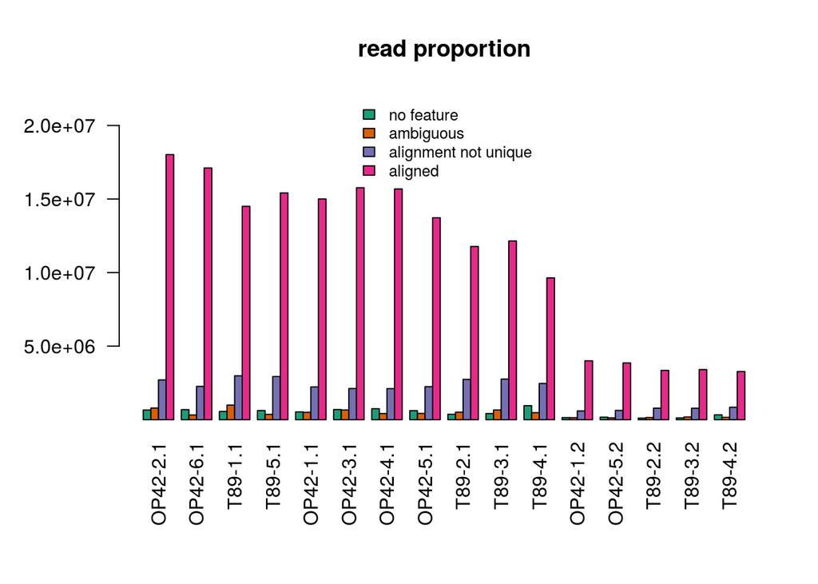

```r
col <- pal[1:nrow(count.stats)]
par(mar=c(7.1,5.1,4.1,2.1))
barplot(as.matrix(count.stats),col=col,beside=TRUE,las=2,main="read proportion",
        ylim=range(count.stats) + c(0,4e+6))
legend("top",fill=col,legend=gsub("_"," ",rownames(count.stats)),bty="n",cex=0.8)
```

```r
par(mar=mar)
```

## 2.2 Combined samples

Combine them

```r
count.table <- sapply(split.data.frame(t(count.table),sub("\\.[1,2]$","",colnames(count.table))),colSums)
count.stats <- sapply(split.data.frame(t(count.stats),sub("\\.[1,2]$","",colnames(count.stats))),colSums)
samples <- samples[!duplicated(sub("\\.[1,2]","",samples$SampleName)),c("SampleName","Line","LineTime","LineTimeSample","Time")]
samples$SampleName <- sub("\\.[1,2]","",samples$SampleName)
samples <- samples[match(colnames(count.table),samples$SampleName),]
```

Look at the stats

```r
pander(apply(count.stats,2,function(co){round(co*100/sum(co))}))
```

Table continues below

|  | OP42-1 | OP42-2 | OP42-3 | OP42-4 | OP42-5 | OP42-6 |
| --- | --- | --- | --- | --- | --- | --- |
| **no_feature** | 3 | 3 | 4 | 4 | 4 | 3 |
| **ambiguous** | 3 | 4 | 3 | 2 | 3 | 2 |
| **alignment_not_unique** | 12 | 12 | 11 | 11 | 13 | 11 |
| **aligned** | 82 | 81 | 82 | 83 | 81 | 84 |

|  | T89-1 | T89-2 | T89-3 | T89-4 | T89-5 |
| --- | --- | --- | --- | --- | --- |
| **no_feature** | 3 | 2 | 3 | 7 | 3 |
| **ambiguous** | 5 | 3 | 4 | 4 | 2 |
| **alignment_not_unique** | 16 | 18 | 17 | 18 | 15 |
| **aligned** | 76 | 76 | 76 | 71 | 80 |

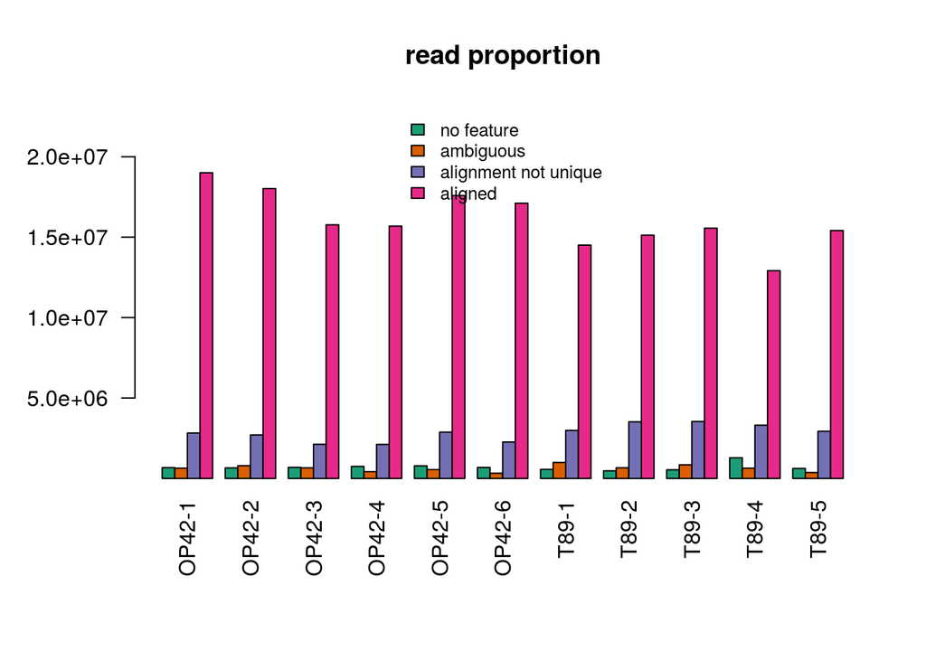

```r
col <- pal[1:nrow(count.stats)]
par(mar=c(7.1,5.1,4.1,2.1))
barplot(as.matrix(count.stats),col=col,beside=TRUE,las=2,main="read proportion",
        ylim=range(count.stats) + c(0,4e+6))
legend("top",fill=col,legend=gsub("_"," ",rownames(count.stats)),bty="n",cex=0.8)
```

```r
par(mar=mar)
```

The average percentage of aligned reads is 79% mean(unlist(count.stats[“aligned”,]/colSums(count.stats)))

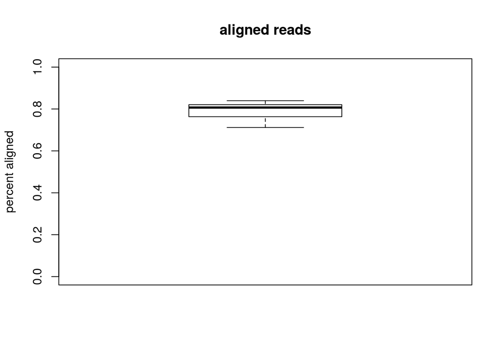

```r
boxplot(unlist(count.stats["aligned",]/colSums(count.stats)),
        main="aligned reads",ylab="percent aligned",ylim=c(0,1))
```

Check how many genes are never expressed

```r
sel <- rowSums(count.table) == 0
sprintf("%s%% percent (%s) of %s genes are not expressed",
        round(sum(sel) * 100/ nrow(count.table),digits=1),
        sum(sel),
        nrow(count.table))
```

```
## [1] "13.8% percent (5689) of 41335 genes are not expressed"
```

Display the per-gene mean expression

i.e. the mean raw count of every gene across samples is calculated and displayed on a log10 scale.

The average cumulative coverage is around 100X

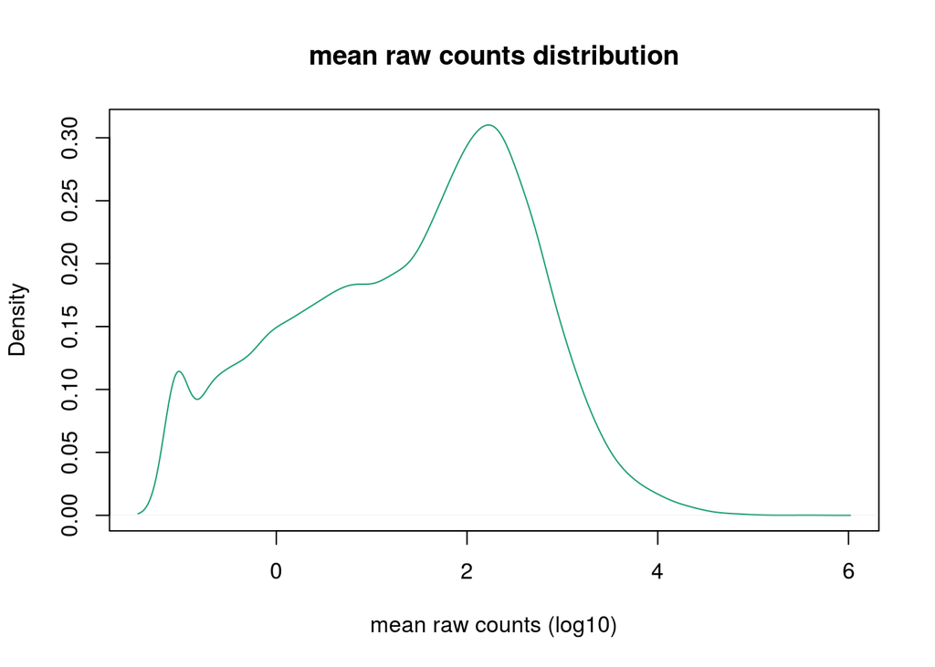

```r
plot(density(log10(rowMeans(count.table))),col=pal[1],
     main="mean raw counts distribution",
     xlab="mean raw counts (log10)")
```

The same is done for the individual The observed distribution is relatively similar, a few samples show slight diffences and there seem to be a trend of more spurious expression for the T89 compared to the OP42. Probably an artefact of the alignment againt P. trichocarpa

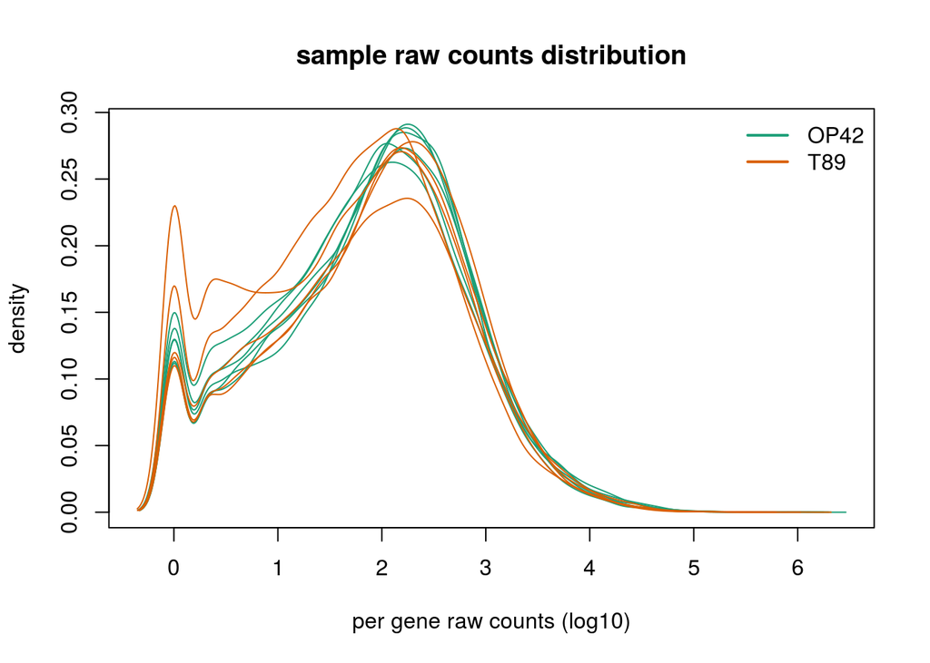

```r
plot.multidensity(lapply(1:ncol(count.table),function(i){log10(count.table[,i])}),
                  col=pal[as.integer(samples$Line)],
                  legend.x="topright",
                  legend=levels(samples$Line),
                  legend.col=pal[1:2],
                  legend.lwd=2,
                  main="sample raw counts distribution",
                  xlab="per gene raw counts (log10)")
```

# 3 Data normalisation

For visualization, the data is submitted to a variance stabilization transformation using DESeq2. The dispersion is estimated independently of the sample tissue and replicate Create the dds object

```r
dds <- DESeqDataSetFromMatrix(
  countData = count.table,
  colData = samples,
  design = ~ Line * Time)
dir.create(file.path("analysis","DE-new"),recursive = TRUE, showWarnings = FALSE)
save(dds,file="analysis/DE-new/DESeqDataset-20170703.rda")
```

Check the size factors (i.e. the sequencing library size effect) There is no big variation, a Variance Stabilizing Transformation can be used (over a Relative Log Transformation)

```r
dds <- estimateSizeFactors(dds)
sizes <- sizeFactors(dds)
names(sizes) <- colnames(count.table)
sizes
```

```
##    OP42-1    OP42-2    OP42-3    OP42-4    OP42-5    OP42-6     T89-1
## 1.1776453 1.1752663 1.0579064 0.9748930 1.0779938 0.9384437 1.2074190
##     T89-2     T89-3     T89-4     T89-5
## 0.9602902 0.9050773 0.8366704 1.1144653
```

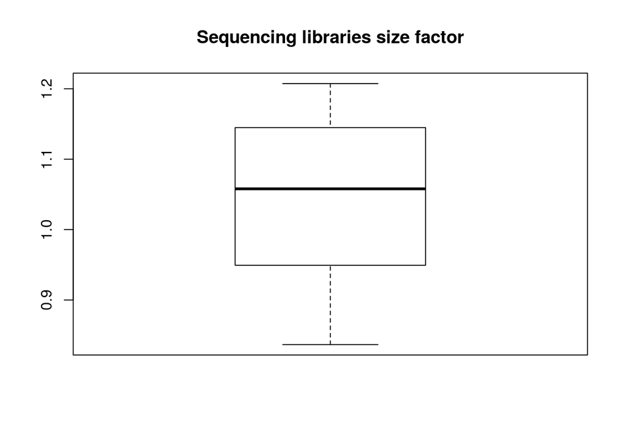

```r
boxplot(sizes, main="Sequencing libraries size factor")
```

Perform the VST

```r
vsd <- varianceStabilizingTransformation(dds, blind=TRUE)
vst <- assay(vsd)
colnames(vst) <- colnames(count.table)
vst <- vst - min(vst)
write.csv(vst,"analysis/HTSeq-new/library-size-normalized_variance-stabilized_data.csv")
```

Validate the VST

Visualize the corrected mean - sd relationship. It is fairly linear, meaning we can assume homoscedasticity. The slight initial trend / bump is due to genes having few counts in a few subset of the samples and hence having a higher variability. This is expected.

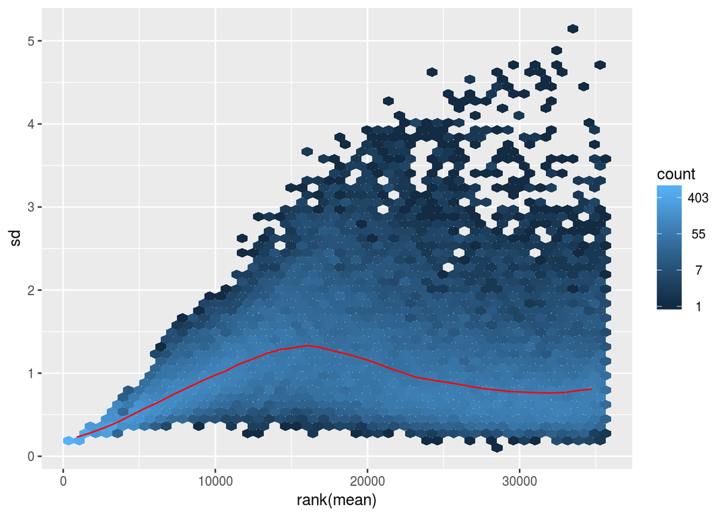

```r
meanSdPlot(vst[rowSums(count.table)>0,])
```

# 4 QC on the normalised data

## 4.1 PCA

First perform a Principal Component Analysis (PCA) of the data to do a quick quality assessment; i.e. replicate should cluster and the first 2-3 dimensions should be explainable by biological means.

```r
pc <- prcomp(t(vst))
percent <- round(summary(pc)$importance[2,]*100)
```

Plot the PCA 3 first dimensions

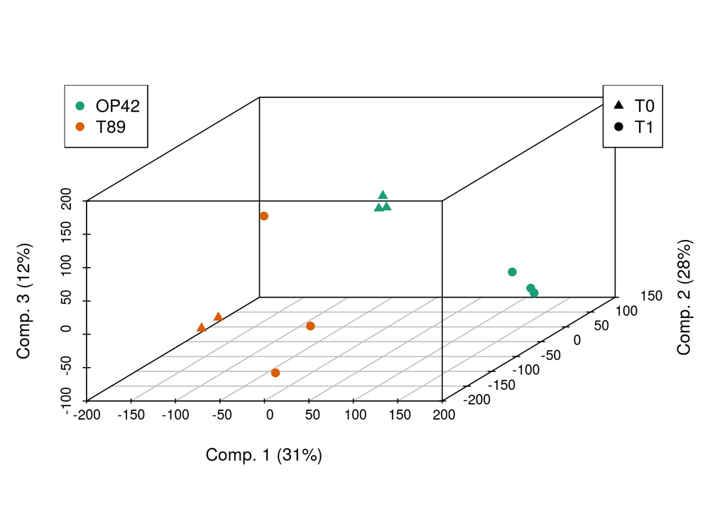

```r
mar=c(5.1,4.1,4.1,2.1)
scatterplot3d(pc$x[,1],
              pc$x[,2],
              pc$x[,3],
              xlab=paste("Comp. 1 (",percent[1],"%)",sep=""),
              ylab=paste("Comp. 2 (",percent[2],"%)",sep=""),
              zlab=paste("Comp. 3 (",percent[3],"%)",sep=""),
              color=pal[as.integer(samples$Line)],
              pch=c(17,19)[as.integer(samples$Time)])
legend("topleft",pch=19,
       col=pal[1:2],
       legend=levels(factor(samples$Line)))

legend("topright",pch=c(17,19),
       legend=levels(factor(samples$Time)))
```

```r
par(mar=mar)
```

Then the first two dimensions The first two dimensions explains the time and the line

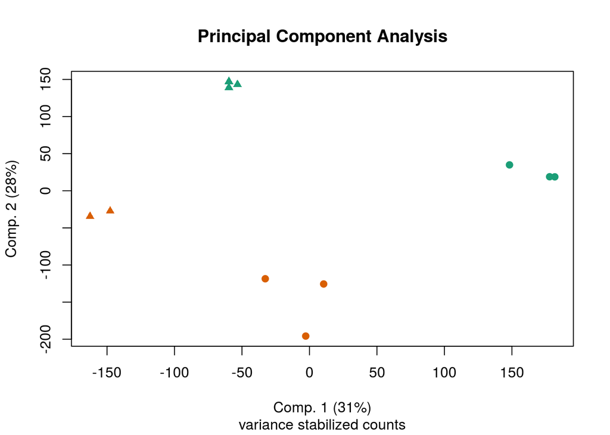

```r
plot(pc$x[,1],
     pc$x[,2],
     xlab=paste("Comp. 1 (",percent[1],"%)",sep=""),
     ylab=paste("Comp. 2 (",percent[2],"%)",sep=""),
     col=pal[as.integer(samples$Line)],
     pch=c(17,19)[as.integer(samples$Time)],
     main="Principal Component Analysis",sub="variance stabilized counts")
```

And the 2nd and 3rd dims

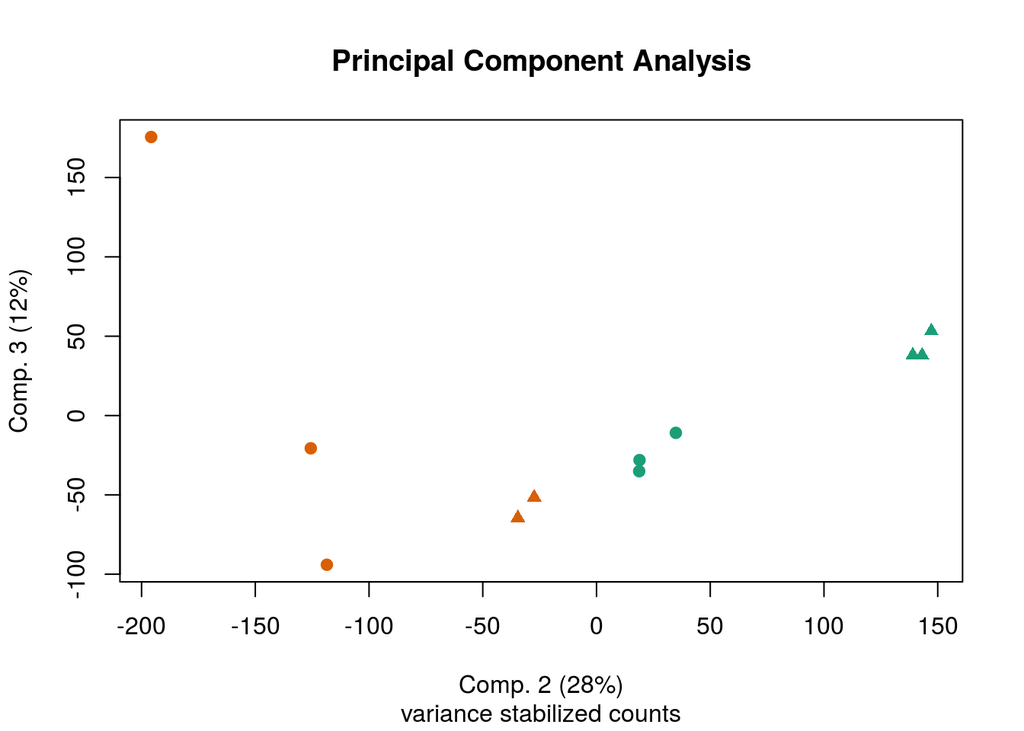

```r
plot(pc$x[,2],
     pc$x[,3],
     xlab=paste("Comp. 2 (",percent[2],"%)",sep=""),
     ylab=paste("Comp. 3 (",percent[3],"%)",sep=""),
     col=pal[as.integer(samples$Line)],
     pch=c(17,19)[as.integer(samples$Time)],
     main="Principal Component Analysis",sub="variance stabilized counts")
```

## 4.2 Heatmap

Select the genes - function

```r
"geneSelect" <- function(cnt,splt,exp=1,nrep=2){
  rowSums(sapply(lapply(
    split.data.frame(t(cnt >= exp),splt)
    ,colSums), ">=", nrep)) >= 1
}
```

Define a cutoff

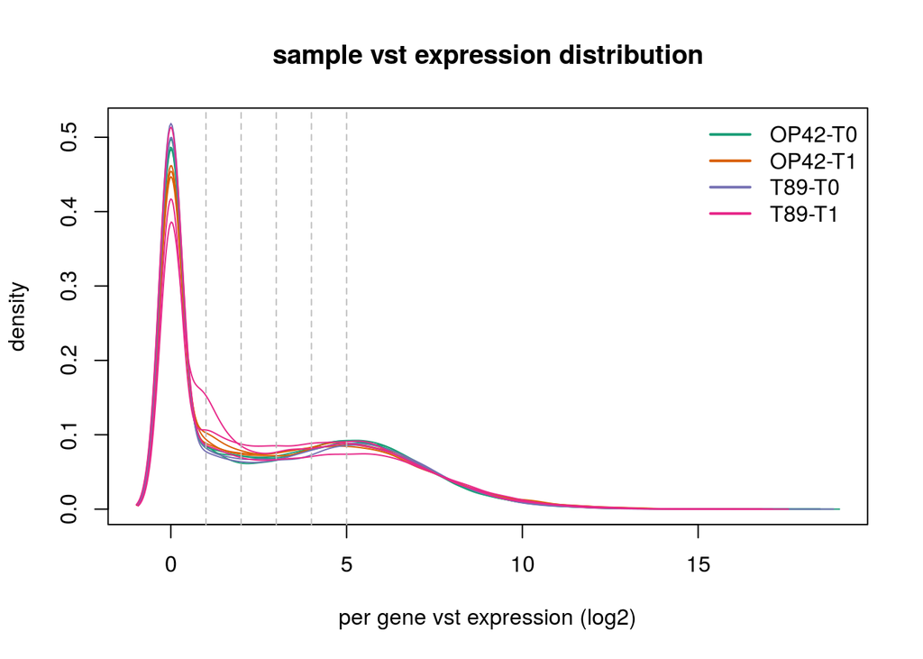

```r
plot.multidensity(lapply(1:ncol(vst),function(i){vst[,i]}),
                  col=pal[as.integer(samples$LineTime)],
                  legend.x="topright",
                  legend=levels(samples$LineTime),
                  legend.col=pal[1:4],
                  legend.lwd=2,
                  main="sample vst expression distribution",
                  xlab="per gene vst expression (log2)")
abline(v=1:5,lty=2,col="grey")
```

We take a cutoff of 3 on the vst table. To keep a gene, it has to be expressed at least above a vst value of 3 in at least 2 replicates of any condition (4 conditions total) This is done only for plotting the heatmap. It could be used for filtering low spuriously expressed genes for other analyses, but is not required for DE.

```r
sel <- geneSelect(vst,samples$LineTime,exp=3)
message(sprintf("There are %s genes that pass the low spurious expression filter.", sum(sel)))
```

```
## There are 21110 genes that pass the low spurious expression filter.
```

The vst clusters the sample first by Time and then by Line The heatmap on the full data is squewed towards blue because of a few highly expressed genes.

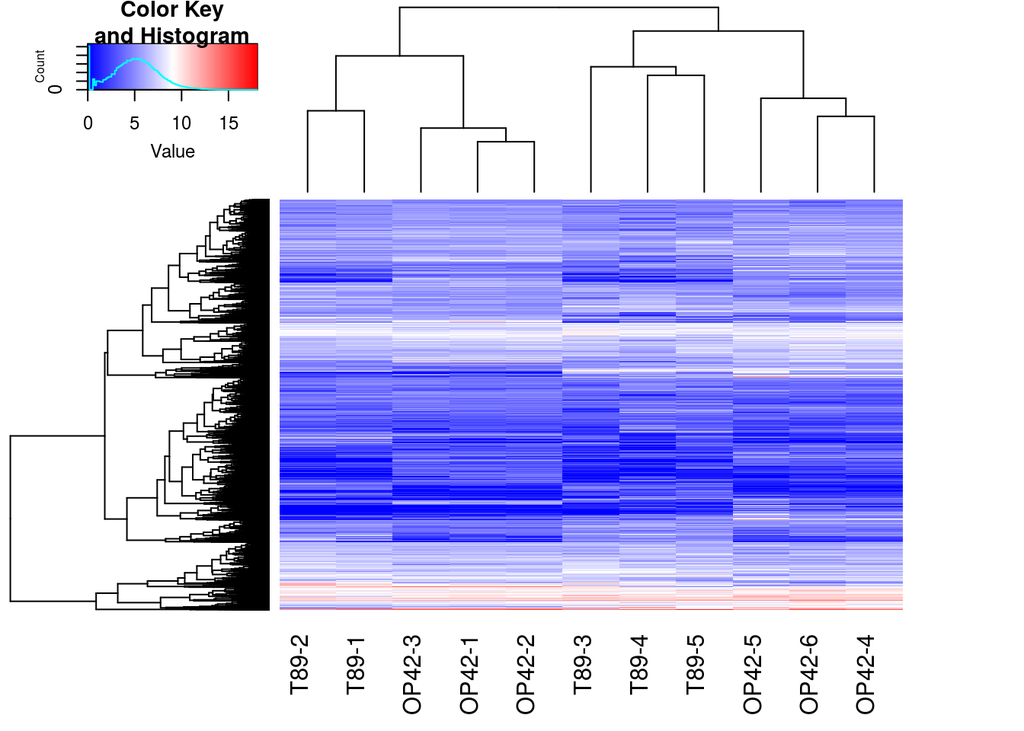

```r
heatmap.2(vst[sel,],trace="none",labRow=FALSE,col=hpal)
```

Plot a dendrogram first

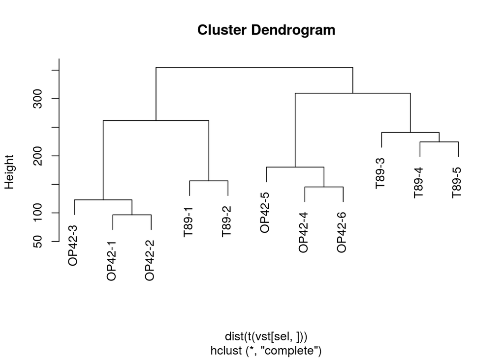

```r
hc <- hclust(dist(t(vst[sel,])))
plot(hc)
```

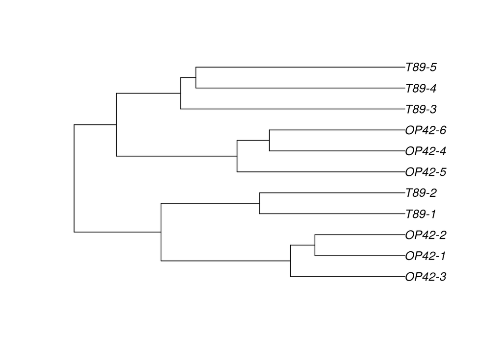

```r
plot(as.phylo.dendrogram(as.dendrogram(hc)))
```

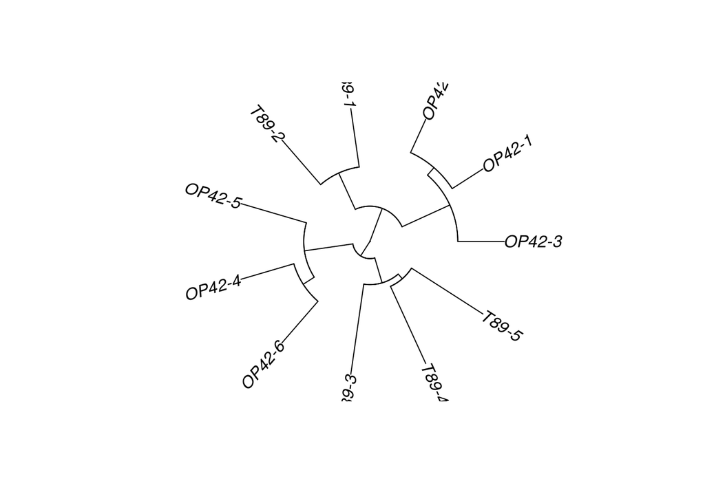

```r
plot(as.phylo.dendrogram(as.dendrogram(hc)),type="fan")
```

Saturate the expression - visualisation only Select cutoffs

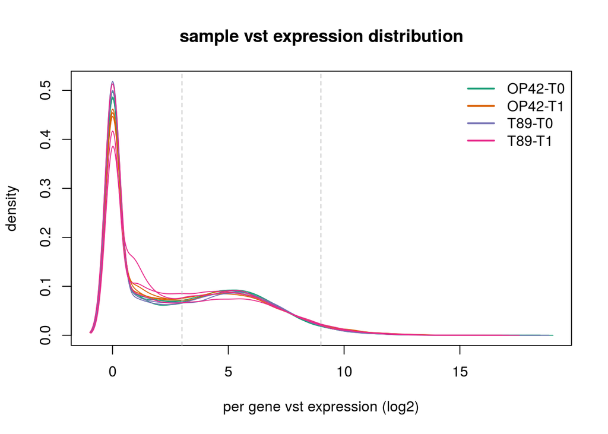

```r
plot.multidensity(lapply(1:ncol(vst),function(i){vst[,i]}),
                  col=pal[as.integer(samples$LineTime)],
                  legend.x="topright",
                  legend=levels(samples$LineTime),
                  legend.col=pal[1:4],
                  legend.lwd=2,
                  main="sample vst expression distribution",
                  xlab="per gene vst expression (log2)")
abline(v=c(3,9),lty=2,col="grey")
```

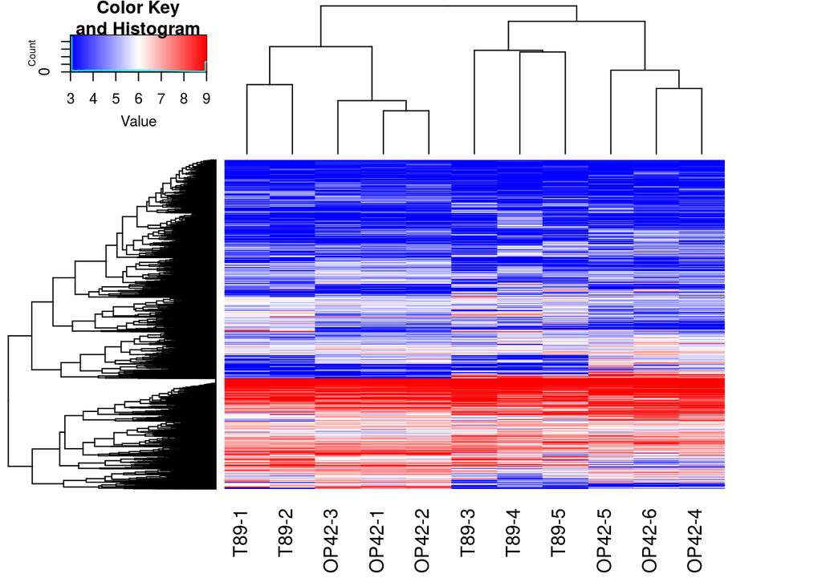

```r
vst.sat <- vst[sel,]
vst.sat[vst.sat < 3] <- 3
vst.sat[vst.sat > 9] <- 9
heatmap.2(vst.sat,trace="none",labRow=FALSE,col=hpal)
```